```python
import pandas as pd
```

# A. Introduction to Pandas DataFrame and Transformation (45pts)

## Beginner

### 1. Membuat DataFrame Manual (5pts)

Buatlah dataframe secara manual seperti gambar dibawah ini.

**Expected Result:**

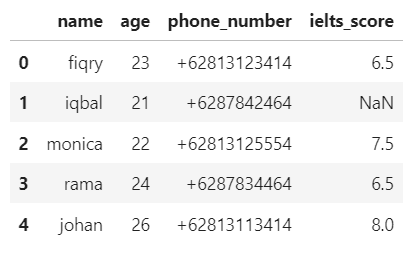

```python
df = pd.DataFrame({
              'name' : ['fiqry','iqbal','monica','rama','johan'],
              'age' : [23,21,22,24,26],
              'phone_number' : ['+62813123414','+6287842464','+62813125554','+6287834464','+62813113414'],
              'ielts_score' : [6.5,None,7.5,6.5,8]})

df
```

|  | name | age | phone_number | ielts_score |
| --- | --- | --- | --- | --- |
| 0 | fiqry | 23 | +62813123414 | 6.5 |
| 1 | iqbal | 21 | +6287842464 | NaN |
| 2 | monica | 22 | +62813125554 | 7.5 |
| 3 | rama | 24 | +6287834464 | 6.5 |
| 4 | johan | 26 | +62813113414 | 8.0 |

### 2. Analisa Sederhana DataFrame (10pts)

Lakukan import `application_processed.csv` data kedalam notebook (5pts) dan carilah beberapa informasi pada dataset `application_processed` (5pts) dan jawablah beberapa pertanyaan sebagai berikut:

a. Column apa saja yang memiliki nilai NaN / None? b. Berapa rata-rata pada column `amount_income_total`? c. Berapa median pada column `amount_income_total`?

**Hint**:

- Menggunakan operasi dasar DataFrame pada topik Introduction Pandas DataFrame and Transformation

```python
df_application_processed = pd.read_csv("F:/COURSE/RAKAMIN/WEEK 5/Homework Data Processing/application_processed.csv")
df_application_processed
```

|  | id | gender | flag_own_car | flag_own_property | total_children | amount_income_total | income_type | education_type | family_status | housing_type | days_birth | days_employed | flag_mobile_phone | flag_work_phone | flag_phone | flag_email | occupation_type | total_family_members |
| --- | --- | --- | --- | --- | --- | --- | --- | --- | --- | --- | --- | --- | --- | --- | --- | --- | --- | --- |
| 0 | 5548815 | Female | 1 | 1 | 1 | 225000.0 | State servant | Secondary / secondary special | Married | House / apartment | -12944 | -6127 | 1 | 0 | 0 | 0 | Laborers | 3.0 |
| 1 | 5692601 | Female | 1 | 1 | 0 | 180000.0 | Working | Secondary / secondary special | Married | House / apartment | -12484 | -1874 | 1 | 0 | 0 | 0 | NaN | 2.0 |
| 2 | 5625007 | Female | 1 | 0 | 0 | 157500.0 | Pensioner | Secondary / secondary special | Widow | House / apartment | -21656 | 365243 | 1 | 0 | 0 | 0 | NaN | 1.0 |
| 3 | 6529653 | Male | 0 | 1 | 0 | 202500.0 | Working | Secondary / secondary special | Married | House / apartment | -10050 | -2117 | 1 | 0 | 0 | 0 | Drivers | 2.0 |
| 4 | 6209935 | Male | 0 | 1 | 1 | 157500.0 | Commercial associate | Secondary / secondary special | Married | House / apartment | -10371 | -1755 | 1 | 0 | 0 | 0 | Drivers | 3.0 |
| ... | ... | ... | ... | ... | ... | ... | ... | ... | ... | ... | ... | ... | ... | ... | ... | ... | ... | ... |
| 131562 | 6108756 | Female | 1 | 1 | 0 | 157500.0 | Working | Higher education | Married | House / apartment | -10867 | -2637 | 1 | 0 | 0 | 0 | Managers | 2.0 |
| 131563 | 5938512 | Male | 1 | 0 | 0 | 202500.0 | Working | Secondary / secondary special | Married | House / apartment | -17815 | -5109 | 1 | 0 | 0 | 0 | NaN | 2.0 |
| 131564 | 6824835 | Male | 1 | 0 | 1 | 225000.0 | State servant | Incomplete higher | Married | House / apartment | -10472 | -3601 | 1 | 0 | 0 | 0 | Security staff | 3.0 |
| 131565 | 5009009 | Male | 0 | 1 | 0 | 166500.0 | Working | Secondary / secondary special | Married | House / apartment | -18926 | -6276 | 1 | 1 | 1 | 0 | Laborers | 2.0 |
| 131566 | 6054185 | Female | 0 | 1 | 2 | 135000.0 | Working | Secondary / secondary special | Married | House / apartment | -11390 | -2736 | 1 | 0 | 0 | 0 | Managers | 4.0 |

131567 rows × 18 columns

```python
#a.
df_application_processed.info()
```

```
<class 'pandas.core.frame.DataFrame'>
RangeIndex: 131567 entries, 0 to 131566
Data columns (total 18 columns):
 #   Column                Non-Null Count   Dtype
---  ------                --------------   -----
 0   id                    131567 non-null  int64
 1   gender                131567 non-null  object
 2   flag_own_car          131567 non-null  int64
 3   flag_own_property     131567 non-null  int64
 4   total_children        131567 non-null  int64
 5   amount_income_total   131567 non-null  float64
 6   income_type           131567 non-null  object
 7   education_type        131567 non-null  object
 8   family_status         131567 non-null  object
 9   housing_type          131567 non-null  object
 10  days_birth            131567 non-null  int64
 11  days_employed         131567 non-null  int64
 12  flag_mobile_phone     131567 non-null  int64
 13  flag_work_phone       131567 non-null  int64
 14  flag_phone            131567 non-null  int64
 15  flag_email            131567 non-null  int64
 16  occupation_type       91472 non-null   object
 17  total_family_members  131567 non-null  float64
dtypes: float64(2), int64(10), object(6)
memory usage: 18.1+ MB
```

```python
#a.
df_mean = df_application_processed['amount_income_total'].mean()
df_mean
```

```
188040.57643679646
```

```python
#c.
df_median = df_application_processed['amount_income_total'].median()
print(df_median)
```

```
162000.0
```

## Intermediate

### 3. Mengolah Dataset (30pts)

Dengan menggunakan dataset `application_processed.csv` buatlah dataframe baru dengan ketentuan:

1. Ambil semua users yang memiliki `email`. (ditandai dengan nilai pada column `flag_email` = 1) dan tidak memilik data `duplicates`. (5pts)
2. Buatlah column baru bernama `has_car_and_property` dimana nilainya merupakan range dari `0-1`. `1` apabila `flag_own_car` bernilai `1` dan `flag_own_property` bernilai `1`. `0` apabila terdapat atau semua nilai pada column `flag_own_car` dan `flag_own_property` terdapat angka 0. (5pts)
3. Ambil column yang diperlukan yaitu `id`, `gender`, `has_car_and_property`, `income_type`, `education_type`, `family_status`, `housing_type`, `occupation_type`, `amount_income_total`. (5pts)
4. Lakukan filter dengan ketentuan sebagai berikut: (5pts)
   - Memiliki `car` dan `property`
   - Tidak ada nilai null pada column `occupation_type`
   - Memiliki value pada column `occupation_type` dengan pola `staff`.
5. Sudah dilakukan sorting berdasarkan `income_type` dari `A-Z` dan `amount_income_total` dari `besar ke kecil`. (5pts)
6. Simpan kedalam bentuk `.csv` dengan nama `homework_3_result.csv`. (5pts)

**Expected Result:**

[figure not shown]

```python
#1.
df_email = df_application_processed[df_application_processed['flag_email']==1]
df_email.drop_duplicates()
```

|  | id | gender | flag_own_car | flag_own_property | total_children | amount_income_total | income_type | education_type | family_status | housing_type | days_birth | days_employed | flag_mobile_phone | flag_work_phone | flag_phone | flag_email | occupation_type | total_family_members |
| --- | --- | --- | --- | --- | --- | --- | --- | --- | --- | --- | --- | --- | --- | --- | --- | --- | --- | --- |
| 5 | 5541414 | Female | 0 | 1 | 0 | 211500.0 | Working | Secondary / secondary special | Civil marriage | House / apartment | -18171 | -1671 | 1 | 0 | 1 | 1 | NaN | 2.0 |
| 8 | 5169560 | Female | 1 | 1 | 0 | 90000.0 | Working | Secondary / secondary special | Married | House / apartment | -16023 | -3532 | 1 | 0 | 0 | 1 | Sales staff | 2.0 |
| 22 | 5884982 | Female | 0 | 1 | 0 | 337500.0 | Commercial associate | Secondary / secondary special | Married | Municipal apartment | -15491 | -703 | 1 | 0 | 1 | 1 | Managers | 2.0 |
| 23 | 6297619 | Male | 1 | 1 | 0 | 360000.0 | Commercial associate | Higher education | Single / not married | Rented apartment | -15796 | -1625 | 1 | 0 | 0 | 1 | High skill tech staff | 1.0 |
| 28 | 6006818 | Female | 0 | 1 | 0 | 247500.0 | Pensioner | Higher education | Married | House / apartment | -23032 | 365243 | 1 | 0 | 0 | 1 | NaN | 2.0 |
| ... | ... | ... | ... | ... | ... | ... | ... | ... | ... | ... | ... | ... | ... | ... | ... | ... | ... | ... |
| 131511 | 5345596 | Male | 1 | 1 | 1 | 112500.0 | Working | Higher education | Married | House / apartment | -17318 | -246 | 1 | 0 | 0 | 1 | Managers | 3.0 |
| 131514 | 5680139 | Female | 0 | 0 | 1 | 67500.0 | Working | Secondary / secondary special | Married | House / apartment | -15140 | -2859 | 1 | 0 | 0 | 1 | Cooking staff | 3.0 |
| 131518 | 5708288 | Female | 0 | 1 | 2 | 135000.0 | Working | Higher education | Married | With parents | -13296 | -2178 | 1 | 0 | 0 | 1 | High skill tech staff | 4.0 |
| 131537 | 5352502 | Female | 1 | 1 | 0 | 103500.0 | Commercial associate | Higher education | Civil marriage | House / apartment | -11772 | -113 | 1 | 0 | 0 | 1 | Accountants | 2.0 |
| 131555 | 6234604 | Female | 1 | 1 | 1 | 171000.0 | Working | Secondary / secondary special | Married | Office apartment | -13908 | -993 | 1 | 0 | 0 | 1 | Sales staff | 3.0 |

12235 rows × 18 columns

```python
#2. = df[‘column_1’] * df[‘column_2’]
df_application_processed['has_car_and_property'] = (df_email['flag_own_car']==1) * (df_email['flag_own_property']==1)
#3.
df_application_processed['has_car_and_property']
```

```
0         NaN
1         NaN
2         NaN
3         NaN
4         NaN
         ...
131562    NaN
131563    NaN
131564    NaN
131565    NaN
131566    NaN
Name: has_car_and_property, Length: 131567, dtype: object
```

```python
#3.
df_final = df_application_processed[['id','gender','has_car_and_property','income_type','education_type','family_status','housing_type','occupation_type','amount_income_total']]
```

```python
#4.
df_final = df_application_processed[(df_application_processed['has_car_and_property'] == 1)
                                                    & (df_application_processed['occupation_type'].str.contains('staff'))
                                                    & (df_application_processed['occupation_type'].notnull())]
#5
df_final.sort_values(by=['income_type','amount_income_total'],ascending=[True, False])
```

|  | id | gender | flag_own_car | flag_own_property | total_children | amount_income_total | income_type | education_type | family_status | housing_type | days_birth | days_employed | flag_mobile_phone | flag_work_phone | flag_phone | flag_email | occupation_type | total_family_members | has_car_and_property |
| --- | --- | --- | --- | --- | --- | --- | --- | --- | --- | --- | --- | --- | --- | --- | --- | --- | --- | --- | --- |
| 52421 | 6604643 | Male | 1 | 1 | 0 | 1350000.0 | Commercial associate | Secondary / secondary special | Single / not married | House / apartment | -17345 | -4819 | 1 | 0 | 1 | 1 | Core staff | 1.0 | True |
| 59763 | 6604646 | Male | 1 | 1 | 0 | 1350000.0 | Commercial associate | Secondary / secondary special | Single / not married | House / apartment | -17345 | -4819 | 1 | 0 | 1 | 1 | Core staff | 1.0 | True |
| 64362 | 6604645 | Male | 1 | 1 | 0 | 1350000.0 | Commercial associate | Secondary / secondary special | Single / not married | House / apartment | -17345 | -4819 | 1 | 0 | 1 | 1 | Core staff | 1.0 | True |
| 24436 | 6423956 | Female | 1 | 1 | 0 | 837000.0 | Commercial associate | Higher education | Married | House / apartment | -18335 | -2035 | 1 | 0 | 0 | 1 | Core staff | 2.0 | True |
| 46430 | 6423956 | Female | 1 | 1 | 0 | 837000.0 | Commercial associate | Higher education | Married | House / apartment | -18335 | -2035 | 1 | 0 | 0 | 1 | Core staff | 2.0 | True |
| ... | ... | ... | ... | ... | ... | ... | ... | ... | ... | ... | ... | ... | ... | ... | ... | ... | ... | ... | ... |
| 52559 | 5021814 | Female | 1 | 1 | 1 | 67500.0 | Working | Secondary / secondary special | Married | House / apartment | -11454 | -1678 | 1 | 0 | 1 | 1 | Cooking staff | 3.0 | True |
| 76315 | 5626688 | Female | 1 | 1 | 1 | 67500.0 | Working | Secondary / secondary special | Married | House / apartment | -12048 | -135 | 1 | 0 | 0 | 1 | Waiters/barmen staff | 3.0 | True |
| 80932 | 5193900 | Female | 1 | 1 | 0 | 67500.0 | Working | Higher education | Married | House / apartment | -17795 | -1424 | 1 | 0 | 0 | 1 | Sales staff | 2.0 | True |
| 117940 | 6659179 | Female | 1 | 1 | 0 | 67500.0 | Working | Secondary / secondary special | Married | House / apartment | -14209 | -3072 | 1 | 0 | 1 | 1 | Core staff | 2.0 | True |
| 73293 | 5936326 | Male | 1 | 1 | 2 | 40500.0 | Working | Secondary / secondary special | Married | House / apartment | -10495 | -656 | 1 | 1 | 0 | 1 | Security staff | 4.0 | True |

1459 rows × 19 columns

```python
#6
df_final.to_csv('homework_3_result.csv',index = False)
pd.read_csv('homework_3_result.csv')
```

|  | id | gender | flag_own_car | flag_own_property | total_children | amount_income_total | income_type | education_type | family_status | housing_type | days_birth | days_employed | flag_mobile_phone | flag_work_phone | flag_phone | flag_email | occupation_type | total_family_members | has_car_and_property |
| --- | --- | --- | --- | --- | --- | --- | --- | --- | --- | --- | --- | --- | --- | --- | --- | --- | --- | --- | --- |
| 0 | 5169560 | Female | 1 | 1 | 0 | 90000.0 | Working | Secondary / secondary special | Married | House / apartment | -16023 | -3532 | 1 | 0 | 0 | 1 | Sales staff | 2.0 | True |
| 1 | 6297619 | Male | 1 | 1 | 0 | 360000.0 | Commercial associate | Higher education | Single / not married | Rented apartment | -15796 | -1625 | 1 | 0 | 0 | 1 | High skill tech staff | 1.0 | True |
| 2 | 5548993 | Female | 1 | 1 | 0 | 405000.0 | Commercial associate | Higher education | Married | House / apartment | -18219 | -3355 | 1 | 0 | 0 | 1 | Core staff | 2.0 | True |
| 3 | 5344333 | Female | 1 | 1 | 0 | 135000.0 | Working | Secondary / secondary special | Married | House / apartment | -13436 | -2859 | 1 | 1 | 1 | 1 | Medicine staff | 2.0 | True |
| 4 | 5499766 | Female | 1 | 1 | 1 | 225000.0 | Working | Secondary / secondary special | Civil marriage | House / apartment | -12881 | -5324 | 1 | 0 | 0 | 1 | Core staff | 3.0 | True |
| ... | ... | ... | ... | ... | ... | ... | ... | ... | ... | ... | ... | ... | ... | ... | ... | ... | ... | ... | ... |
| 1454 | 6046953 | Male | 1 | 1 | 0 | 450000.0 | State servant | Higher education | Single / not married | House / apartment | -8509 | -913 | 1 | 0 | 0 | 1 | Core staff | 1.0 | True |
| 1455 | 6484818 | Male | 1 | 1 | 0 | 315000.0 | Working | Higher education | Married | House / apartment | -10713 | -1481 | 1 | 0 | 0 | 1 | Sales staff | 2.0 | True |
| 1456 | 5883006 | Female | 1 | 1 | 0 | 157500.0 | State servant | Higher education | Single / not married | House / apartment | -11130 | -4177 | 1 | 0 | 0 | 1 | Medicine staff | 1.0 | True |
| 1457 | 6728550 | Female | 1 | 1 | 0 | 157500.0 | Working | Incomplete higher | Civil marriage | House / apartment | -11454 | -750 | 1 | 0 | 0 | 1 | Core staff | 2.0 | True |
| 1458 | 6234604 | Female | 1 | 1 | 1 | 171000.0 | Working | Secondary / secondary special | Married | Office apartment | -13908 | -993 | 1 | 0 | 0 | 1 | Sales staff | 3.0 | True |

1459 rows × 19 columns

# B.DataFrame Aggregation (25pts)

## Intermediate

### 4. Group By and Aggregate (10pts)

Dengan menggunakan data `titanic.csv`, buatlah dataframe untuk melihat informasi `max` dan `min` pada column `Age` dan juga informasi `mean` dan `median` pada column `Fare` pada masing-masing PassengerClass atau `Pclass`.

**Expected Result:**

[figure not shown]

```python
titanic = pd.read_csv(r'F:/COURSE/RAKAMIN/WEEK 5/Homework Data Processing/titanic.csv')
titanic
```

|  | PassengerId | Survived | Pclass | Name | Sex | Age | SibSp | Parch | Ticket | Fare | Cabin | Embarked |
| --- | --- | --- | --- | --- | --- | --- | --- | --- | --- | --- | --- | --- |
| 0 | 1 | 0 | 3 | Braund, Mr. Owen Harris | male | 22.0 | 1 | 0 | A/5 21171 | 7.2500 | NaN | S |
| 1 | 2 | 1 | 1 | Cumings, Mrs. John Bradley (Florence Briggs Th... | female | 38.0 | 1 | 0 | PC 17599 | 71.2833 | C85 | C |
| 2 | 3 | 1 | 3 | Heikkinen, Miss. Laina | female | 26.0 | 0 | 0 | STON/O2. 3101282 | 7.9250 | NaN | S |
| 3 | 4 | 1 | 1 | Futrelle, Mrs. Jacques Heath (Lily May Peel) | female | 35.0 | 1 | 0 | 113803 | 53.1000 | C123 | S |
| 4 | 5 | 0 | 3 | Allen, Mr. William Henry | male | 35.0 | 0 | 0 | 373450 | 8.0500 | NaN | S |
| ... | ... | ... | ... | ... | ... | ... | ... | ... | ... | ... | ... | ... |
| 886 | 887 | 0 | 2 | Montvila, Rev. Juozas | male | 27.0 | 0 | 0 | 211536 | 13.0000 | NaN | S |
| 887 | 888 | 1 | 1 | Graham, Miss. Margaret Edith | female | 19.0 | 0 | 0 | 112053 | 30.0000 | B42 | S |
| 888 | 889 | 0 | 3 | Johnston, Miss. Catherine Helen "Carrie" | female | NaN | 1 | 2 | W./C. 6607 | 23.4500 | NaN | S |
| 889 | 890 | 1 | 1 | Behr, Mr. Karl Howell | male | 26.0 | 0 | 0 | 111369 | 30.0000 | C148 | C |
| 890 | 891 | 0 | 3 | Dooley, Mr. Patrick | male | 32.0 | 0 | 0 | 370376 | 7.7500 | NaN | Q |

891 rows × 12 columns

```python
df_titanic = titanic.groupby('Pclass').agg({'Age' : ['max','min'],
                                          'Fare' : ['mean','median']})
df_titanic
```

| Pclass | Age max | Age min | Fare mean | Fare median |
| --- | --- | --- | --- | --- |
| 1 | 80.0 | 0.92 | 84.154687 | 60.2875 |
| 2 | 70.0 | 0.67 | 20.662183 | 14.2500 |
| 3 | 74.0 | 0.42 | 13.675550 | 8.0500 |

### 5. Memanfaatkan Pivot Tabel (15pts)

Buatlah dataframe baru menggunakan fungsi pivot table untuk melihat `Embarked` apa saja yang `average_female_ticket_price` lebih besar daripada `average_male_ticket_price`. Informasi `average_female_ticket_price` dan `average_male_ticket_price` didapatkan dari rata-rata pada column `Fare`.

**Hint:**

1. menggunakan pivot table
2. dapat dilihat pada topik `DataFrame Aggregation` bagian `Pivot Table | Reshape Columns and Rows`

**Expected Result:**

[figure not shown]

```python
import pandas as pd
titanic_pivot = pd.pivot_table(titanic, values = 'Fare',
                                 index = 'Embarked',
                                 columns = 'Sex',
                                 aggfunc = 'mean'
                                )
titanic_df = titanic_pivot[titanic_pivot['female'] > titanic_pivot['male']]
titanic_df
```

| Sex Embarked | female | male |
| --- | --- | --- |
| C | 75.169805 | 48.262109 |
| S | 38.740929 | 21.711996 |

# C. DataFrame Combination (30pts)

## 6. Melakukan Append pada DataFrame (5pts)

Buatlah DataFrame seperti pada soal `no.1`. Kemudian tambahkan data tersebut dengan data users yang baru seperti gambar dibawah berikut.

**New Users Data:**

[figure not shown]

**Expected Result:**

[figure not shown]

```python
df = pd.DataFrame({
              'name' : ['fiqry','iqbal','monica','rama','johan'],
              'age' : [23,21,22,24,26],
              'phone_number' : ['+62813123414','+6287842464','+62813125554','+6287834464','+62813113414'],
              'ielts_score' : [6.5,None,7.5,6.5,8]})
df
```

|  | name | age | phone_number | ielts_score |
| --- | --- | --- | --- | --- |
| 0 | fiqry | 23 | +62813123414 | 6.5 |
| 1 | iqbal | 21 | +6287842464 | NaN |
| 2 | monica | 22 | +62813125554 | 7.5 |
| 3 | rama | 24 | +6287834464 | 6.5 |
| 4 | johan | 26 | +62813113414 | 8.0 |

```python
dictionary = pd.DataFrame({'name' : ['ali','adit'],
              'age' : [37,32],
              'phone_number' : [None, '+62152155',],
              'ielts_score' : [5.5,6.0]})
data_users = df.append(dictionary, ignore_index = True)
data_users
```

|  | name | age | phone_number | ielts_score |
| --- | --- | --- | --- | --- |
| 0 | fiqry | 23 | +62813123414 | 6.5 |
| 1 | iqbal | 21 | +6287842464 | NaN |
| 2 | monica | 22 | +62813125554 | 7.5 |
| 3 | rama | 24 | +6287834464 | 6.5 |
| 4 | johan | 26 | +62813113414 | 8.0 |
| 5 | ali | 37 | None | 5.5 |
| 6 | adit | 32 | +62152155 | 6.0 |

### 7. Merge DataFrame (25pts)

Buatlah 2 dataframe mengikuti petunjuk berikut:

df_1 : Filter dataset 01 telecom_revenue.csv dengan multiple kondisi (5pts)

- MonthlyRevenue > 10
- Occupation terdiri dari Professional, Student, and Crafts

df_2 : Filter dataset 02 telecom_usage.csv dengan multiple kondisi (5pt)

- nilai UnansweredCalls > BlockedCalls

Jawablah pertanyaan berikut ini:

1. Hitunglah total CustomerID dan rata-rata DroppedCalls untuk masing-masing occupation. (10 Points)
2. Pada occupation apa, rata-rata DroppedCalls paling besar? (5 Points)

**Expected Result:**

[figure not shown]

```python
import pandas as pd
telcom_revenue = pd.read_csv(r'F:\COURSE\RAKAMIN\WEEK 5\Homework Data Processing\01 telecom_revenue.csv')
telcom_revenue
```

|  | CustomerID | Churn | MonthlyRevenue | MonthlyMinutes | TotalRecurringCharge | OverageMinutes | RoamingCalls | Occupation |
| --- | --- | --- | --- | --- | --- | --- | --- | --- |
| 0 | 3164846 | No | 34.91 | 619.0 | 18.0 | 53.0 | 0.0 | Other |
| 1 | 3203230 | Yes | 43.24 | 405.0 | 40.0 | 0.0 | 0.0 | Other |
| 2 | 3371590 | No | 73.47 | 1281.0 | 71.0 | 0.0 | 0.0 | Other |
| 3 | 3138302 | No | 776.27 | 3978.0 | 160.0 | 2278.0 | 22.9 | Other |
| 4 | 3375774 | No | 189.20 | 1474.0 | 95.0 | 0.0 | 0.0 | Other |
| ... | ... | ... | ... | ... | ... | ... | ... | ... |
| 9995 | 3267618 | No | 30.14 | 152.0 | 40.0 | 0.0 | 0.0 | Other |
| 9996 | 3316790 | No | 50.61 | 260.0 | 58.0 | 0.0 | 0.3 | Other |
| 9997 | 3265178 | Yes | 87.18 | 960.0 | 85.0 | 0.0 | 0.0 | Other |
| 9998 | 3282934 | Yes | 31.24 | 134.0 | 40.0 | 0.0 | 0.0 | Clerical |
| 9999 | 3017238 | No | 56.80 | 426.0 | 30.0 | 73.0 | 0.0 | Other |

10000 rows × 8 columns

```python
telcom_usage = pd.read_csv(r'F:\COURSE\RAKAMIN\WEEK 5\Homework Data Processing\02 telecom_usage.csv')
telcom_usage
```

|  | CustomerID | DroppedCalls | BlockedCalls | UnansweredCalls | CustomerCareCalls |
| --- | --- | --- | --- | --- | --- |
| 0 | 3389874 | 0.0 | 1.0 | 7.7 | 0.7 |
| 1 | 3282042 | 15.3 | 1.7 | 152.0 | 5.7 |
| 2 | 3054454 | 8.7 | 0.3 | 30.3 | 0.0 |
| 3 | 3091842 | 6.0 | 1.7 | 19.3 | 0.0 |
| 4 | 3382382 | 0.7 | 0.7 | 5.0 | 0.0 |
| ... | ... | ... | ... | ... | ... |
| 4995 | 3302462 | 6.7 | 0.0 | 4.7 | 0.0 |
| 4996 | 3169318 | 0.0 | 43.3 | 23.7 | 7.7 |
| 4997 | 3066482 | 0.0 | 3.0 | 3.3 | 0.0 |
| 4998 | 3059734 | 0.3 | 0.7 | 2.0 | 0.0 |
| 4999 | 3224474 | 6.7 | 1.0 | 32.7 | 0.0 |

5000 rows × 5 columns

```python
df_1 =  telcom_revenue[(telcom_revenue['MonthlyRevenue']>10)& (telcom_revenue['Occupation'].isin(['Professional','Student','Crafts']))]
df_2 = telcom_usage[telcom_usage['UnansweredCalls']>telcom_usage['BlockedCalls']]
merger = df_1.merge(df_2, on = 'CustomerID')
merger.groupby('Occupation').agg({'CustomerID' : [len],
                                 'DroppedCalls':['mean']})
```

| Occupation | CustomerID len | DroppedCalls mean |
| --- | --- | --- |
| Crafts | 24 | 6.191667 |
| Professional | 128 | 5.532813 |
| Student | 5 | 8.220000 |